# A3: SPL Library Checkouts

Nick Ng

### Introduction

The values I’d like to calculate is the proportion of each usage class checked out over time. As our technology develops in this day in age, I’m curious on the usage of digital checkouts and how many people are transitioning to electronic methods. I’m also curious on whichh types of materials are used the most. Especially because of the pandemic, I’m interested in finding out how each material type changed over time. Literature and fictions are two of the most favored genre and I’m curious on their checked out amounts over time.

### Summary Information

- What is the change in proportion of usage class items over time?

  In the second graph we’re able to see that users converted over to digital usage from physical in 2020. This is not surprising since this is when covid started and people were locked down.
- Which month had the greatest proportion of digital usage items?

  In the second graph, we’re able to see that 2020 had the most amount of digital usage. Again, since it was the pandemic, this information is not suprising to me.
- What is the year with the most amount of audiobook checkouts?

  2022 has the most amount of audiobooks checked out from 2013-2023. We can see there has been an increase in audiobook usage from 2013-2022.
- How did the top 5 material type checkout change over time?

  We can see that books, video disks, and sound disks are decreasing demand as ebooks and audiobooks are becoming more popular in this day in age.
- How did the number of fiction versus literature books change over time?

### The Dataset

- Who collected/published the data?

  The data is provided by the Seattle Public Library and the dataset owner is David Christensen
- What are the parameters of the data (dates, number of checkouts, kinds of books, etc.)?

  UsageClass, CheckoutType, MaterialType, CheckoutYear, CheckoutMonth, Checkouts, Title, ISBN, Creator, Subjects, Publisher, and PublicationYear.
- How was the data collected or generated?

  Collected monthly by title for physical and digital items. There are 12 columns for information given but the ISBN column is empty ensure privacy. In this dataset, we have 4224916 rows meaning we have 4224916 different items through the year checked out.
- Why was the data collected?

  This data was collected to not only keep track of which items were checked out, but also allows the library to find trends in their popular/non-popular items.
- What, if any, ethical questions do you need to consider when working with this data?

  Did the borrowers give us consent to keep track of their checkout items and whether or not they think this information is sensitive or not.
- What are possible limitations or problems with this data? (at least 200 words)

  Some limitations with this data is the ability to see what people checkout together. For example, we’re not able to see whether people who checkout fiction only like fictions or they enjoy fiction best with history. Understanding correlations can allows the library to arrange their books to where checking out books can be closer together. Since this data only shows how many times a certain item is checked out, we cannot determine this information from it.

  One problem with this dataset is that this dataset only provides the items that are checked out 5 times within a month. Those that are checked out 4 or less times is not included in this dataset and can cause this dataset to be unrepresentative of the actual trends. There may be a lot of checked out history books that aren’t checked out very often but because of this dataset, we aren’t able to see it.

  Another problem with this dataset is that it does not provide us with what changed during the pandemic. How accessible was the online library? How did the checking out process work? How many people knew about it? These are all questions that can affect about my people use the library during COVID and affect the number of checked out items between physical and digital.

### First Trends Over Time chart

```
## # A tibble: 5 × 2
##   MaterialType   total
##   <chr>          <int>
## 1 AUDIOBOOK     500958
## 2 BOOK         1775213
## 3 EBOOK         805613
## 4 SOUNDDISC     262693
## 5 VIDEODISC     822000
```

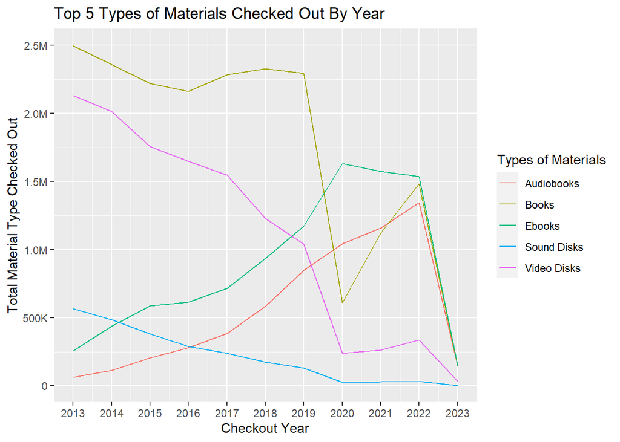

We’re able to see that Ebooks soared during 2020 and this can be the cause of the pandemic. People were locked down and so they coverted to electronic books and why regular books dropped too. We also see that video and sound discs are becoming less common over the year. Audiobooks also increased over time as well.

### Second Trends Over Time Chart

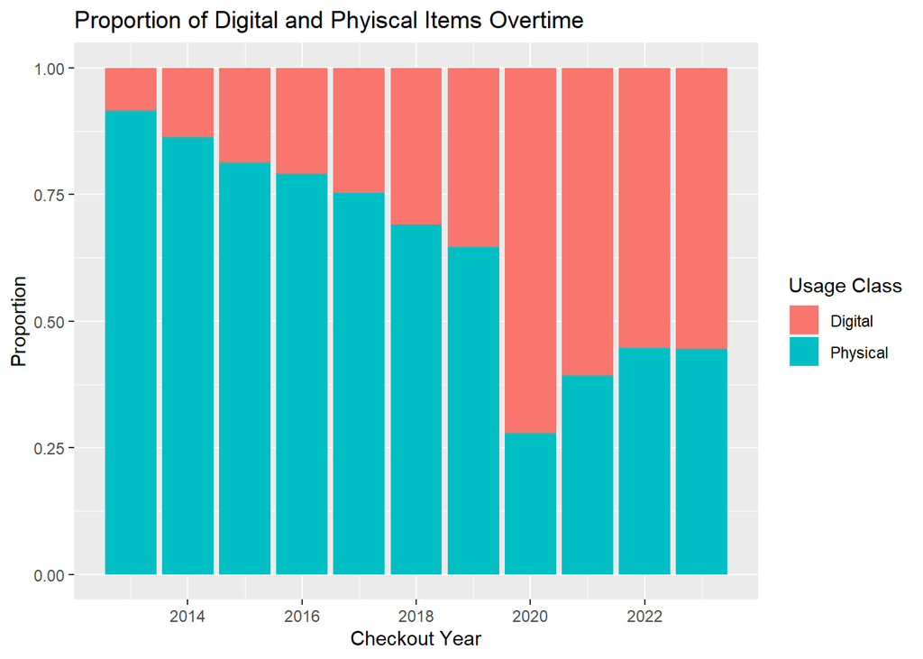

In this stacked bar chart, we’re able to see that digital usage took over during 2020. 2020 is the start of the pandemic and so this can be the reason why digital usage took over.

### Your Choice

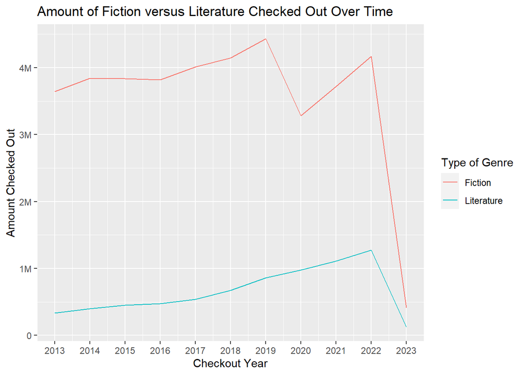

In this graph, we’re able to see that fiction story books are superiorly more popular than literate books throughout the years. We do notice that people started to read less fiction in 2020, the same year of the start of the pandemic but we cannot determine the cause of this from this dataset.